```python
import numpy as np
import pandas as pd
import matplotlib as mlp
import matplotlib.pyplot as plt
import seaborn as sns
from scipy.stats import linregress
import scipy.stats as stats
import matplotlib.font_manager as fm

font_name = fm.FontProperties(fname="C:\\Windows\\Fonts\\malgun.ttf").get_name()
plt.rc("font", family = font_name)
mlp.rcParams["axes.unicode_minus"] = False
```

# TOPIC : 혼인상태와 부채

## Data Definition

- 한국여성정책연구원,「혼인상태별 인구(성/연령별)」
  - https://gsis.kwdi.re.kr/statHtml/statHtml.do?orgId=338&tblId=DT_1IN0508&conn_path=I2
- 통계청, 한국은행, 금융감독원,「가계금융복지조사」, 2017, 2023.04.28, 가구주연령계층별(10세) 자산, 부채, 소득 현황
  - https://kosis.kr/statHtml/statHtml.do?orgId=101&tblId=DT_1J20112&conn_path=I2

```python
age_marr_rat = pd.read_csv(r"../csv/m_status_3.csv", header=[0,1])
```

```python
debt_house_2010 = pd.read_csv(r"../csv/가구주연령계층별_10세__자산__부채__소득_현황_2010.csv", header = [0], encoding="EUC-KR")
debt_house_2012 = pd.read_csv(r"../csv/가구주연령계층별_10세__자산__부채__소득_현황_2012.csv", header = [0], encoding="EUC-KR")
debt_house_2017 = pd.read_csv(r"../csv/가구주연령계층별_10세__자산__부채__소득_현황_2017.csv", header = [0], encoding="EUC-KR")
```

## EDA & Preprocessing

### 혼인상태 별 인구데이터 전처리

- 나이대별 혼인비율 데이터프레임으로 전처리

```python
age_marr_rat = age_marr_rat.T
age_marr_rat = age_marr_rat.reset_index()

age_marr_rat.iloc[1,0] = "연도"
age_marr_rat.iloc[1,1] = "분류"
age_marr_rat.columns = age_marr_rat.loc[1,:]
age_marr_rat = age_marr_rat.iloc[2:,:]

age_marr_rat = age_marr_rat[age_marr_rat.분류 == "비율"]
age_marr_rat = age_marr_rat.drop('분류', axis=1)
age_marr_rat.head(10)
```

| 1 | 연도 | 20~24세 | 25~29세 | 30~34세 | 35~39세 |
| --- | --- | --- | --- | --- | --- |
| 4 | 1985 | 0.835984 | 0.344959 | 0.068845 | 0.021561 |
| 7 | 1990 | 0.887993 | 0.396457 | 0.096931 | 0.031117 |
| 10 | 1995 | 0.900526 | 0.470669 | 0.131682 | 0.049922 |
| 13 | 2000 | 0.935196 | 0.556234 | 0.194924 | 0.074925 |
| 16 | 2005 | 0.960313 | 0.705731 | 0.302206 | 0.130108 |
| 19 | 2010 | 0.975134 | 0.775143 | 0.397658 | 0.196814 |
| 22 | 2015 | 0.978977 | 0.839494 | 0.469252 | 0.262037 |
| 25 | 2020 | 0.986075 | 0.873785 | 0.563923 | 0.307423 |

#### 2010부터 2022년까지의 기울기 예측

- 데이터 타입 변경
  - Object to Numeric

```python
age_marr_rat["연도"] = pd.to_numeric(age_marr_rat["연도"])
age_marr_rat["30~34세"] = pd.to_numeric(age_marr_rat["30~34세"])

for column in  age_marr_rat.columns:
    age_marr_rat[column] = pd.to_numeric(age_marr_rat[column])

age_marr_rat
```

| 1 | 연도 | 20~24세 | 25~29세 | 30~34세 | 35~39세 |
| --- | --- | --- | --- | --- | --- |
| 4 | 1985 | 0.835984 | 0.344959 | 0.068845 | 0.021561 |
| 7 | 1990 | 0.887993 | 0.396457 | 0.096931 | 0.031117 |
| 10 | 1995 | 0.900526 | 0.470669 | 0.131682 | 0.049922 |
| 13 | 2000 | 0.935196 | 0.556234 | 0.194924 | 0.074925 |
| 16 | 2005 | 0.960313 | 0.705731 | 0.302206 | 0.130108 |
| 19 | 2010 | 0.975134 | 0.775143 | 0.397658 | 0.196814 |
| 22 | 2015 | 0.978977 | 0.839494 | 0.469252 | 0.262037 |
| 25 | 2020 | 0.986075 | 0.873785 | 0.563923 | 0.307423 |

- 기울기와 절편

```python
year_list = list(range(2010,2023))

for year in year_list:
    row_dict = dict()
    row_dict['연도'] = year
    for column in  age_marr_rat.columns[1:]:
        x = age_marr_rat['연도']
        y = age_marr_rat[column]
        slope1, slope2, intercept = np.polyfit(x, y, 2)
        row_dict[column] = (slope1 * year * year + slope2 * year + intercept)

    age_marr_rat = age_marr_rat.append(row_dict, ignore_index=True)

age_marr_rat = age_marr_rat[(2010-2023):]
```

- 데이터프레임 전치 및 컬럼명 변경

```python
age_marr_rat = age_marr_rat.set_index("연도")
age_marr_rat = age_marr_rat.T.stack().reset_index()
```

```python
age_marr_rat.columns = ["연령","연도","미혼율"]
age_marr_rat.head()
```

|  | 연령 | 연도 | 미혼율 |
| --- | --- | --- | --- |
| 0 | 20~24세 | 2010.0 | 0.972483 |
| 1 | 20~24세 | 2011.0 | 0.974819 |
| 2 | 20~24세 | 2012.0 | 0.976926 |
| 3 | 20~24세 | 2013.0 | 0.978803 |
| 4 | 20~24세 | 2014.0 | 0.980449 |

### 가구당 부채 보유액 데이터전처리

- 데이터 통일화(30세 미만 -> 29세 이하)

```python
debt_house_2010 = debt_house_2010.iloc[:,[1,-2,-1]]
debt_house_2012 = debt_house_2012.iloc[:,[1,-2,-1]]
debt_house_2017 = debt_house_2017.iloc[:,[1,-2,-1]]
```

```python
columns = ["연령","연도","부채보유액"]

debt_house_2010.columns = columns
debt_house_2012.columns = columns
debt_house_2017.columns = columns

debt_house_2010.loc[(debt_house_2010['연령'] == "30세 미만"),"연령"] = "29세 이하"
```

- 분리되어 있는 가구당 부채 보유액 데이터를 하나로 병합

```python
debt_house = pd.concat([debt_house_2010,debt_house_2012,debt_house_2017])
debt_house = debt_house.sort_values(by=["연령","연도"])
```

```python
age_marr_rat_25_34 = age_marr_rat[(age_marr_rat["연령"] == "25~29세") | (age_marr_rat["연령"] == "30~34세")].groupby("연도").mean()
age_marr_rat_25_34["연령"] = "25~34세"

age_marr_rat_35_44 = age_marr_rat[(age_marr_rat["연령"] == "35~39세") | (age_marr_rat["연령"] == "40~44세")].groupby("연도").mean()
age_marr_rat_35_44["연령"] = "35~44세"
```

```python
age_marr_rat_25_34 = age_marr_rat_25_34.reset_index()
age_marr_rat_35_44 = age_marr_rat_35_44.reset_index()
```

```python
age_marr_rat_25_34["연도"] = age_marr_rat_25_34["연도"] - 5
age_marr_rat_35_44["연도"] = age_marr_rat_35_44["연도"] - 5
```

```python
age_marr_rat_25_34["연도"] = age_marr_rat_25_34["연도"].astype("int")
age_marr_rat_35_44["연도"] = age_marr_rat_35_44["연도"].astype("int")
```

```python
debt_house_20_29 = debt_house[debt_house["연령"]=="29세 이하"]
debt_house_30_39 = debt_house[debt_house["연령"]=="30~39세"]
```

```python
merged_debt_marr_20_29 = pd.merge(debt_house_20_29,age_marr_rat_25_34, on=['연도'])
merged_debt_marr_30_39 = pd.merge(debt_house_30_39,age_marr_rat_35_44, on=['연도'])
```

### 시각화

#### 29세이하 평균 부채에 따른 5년 후 미혼율 분석 시각화

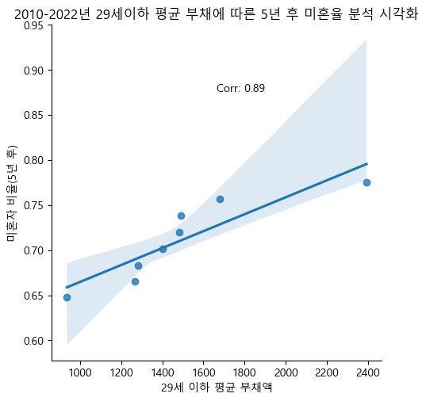

```python
sns.lmplot(data = merged_debt_marr_20_29, x="부채보유액", y="미혼율")
plt.title("2010-2022년 29세이하 평균 부채에 따른 5년 후 미혼율 분석 시각화")
plt.xlabel('29세 이하 평균 부채액')
plt.ylabel('미혼자 비율(5년 후)')
corr_coef= np.corrcoef(merged_debt_marr_20_29["부채보유액"], merged_debt_marr_20_29["미혼율"])[0,1]
plt.gca().annotate(f"Corr: {corr_coef:.2f}", xy=(0.5, 0.8), xycoords=plt.gca().transAxes)
plt.show()
```

#### 30-39세 평균 부채에 따른 5년 후 미혼율 분석 시각화

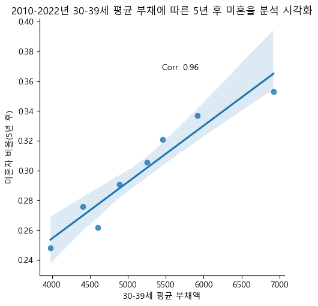

```python
sns.lmplot(data = merged_debt_marr_30_39, x="부채보유액", y="미혼율")
plt.title("2010-2022년 30-39세 평균 부채에 따른 5년 후 미혼율 분석 시각화")
plt.xlabel('30-39세 평균 부채액')
plt.ylabel('미혼자 비율(5년 후)')
corr_coef= np.corrcoef(merged_debt_marr_30_39["부채보유액"], merged_debt_marr_30_39["미혼율"])[0,1]
plt.gca().annotate(f"Corr: {corr_coef:.2f}", xy=(0.5, 0.8), xycoords=plt.gca().transAxes)
plt.show()
```

```python
merged_debt_marr = pd.concat([merged_debt_marr_20_29,merged_debt_marr_30_39])
```

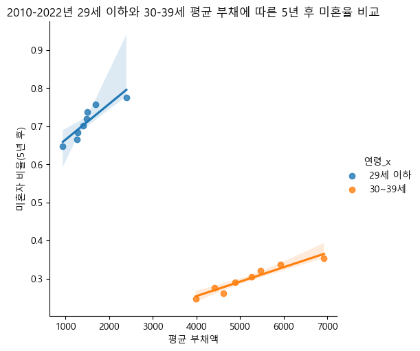

```python
sns.lmplot(data = merged_debt_marr, x="부채보유액", y="미혼율", hue="연령_x")
plt.title("2010-2022년 29세 이하와 30-39세 평균 부채에 따른 5년 후 미혼율 비교")
plt.xlabel('평균 부채액')
plt.ylabel('미혼자 비율(5년 후)')
plt.show()
```

- 부채액의 상승에 따른 5년 후의 미혼율 증가하는 현상이 발생하는 것으로 확인되었다.
- 연령대가 높아질 수록 부채액이 미혼율에 미치는 영향력의 상관성은 더 강한 것으로 나타났으나
- 연령대가 어려질 수록 부채액의 정도에 따라 더욱 가파르게 미혼율이 증가하는 것으로 나타났다.

### 차이검정

#### 정규성 확인

```python
x1 = merged_debt_marr_20_29["미혼율"]
t_stat_x1, p_val_x1 = stats.kstest(x1, 'norm', args=(x1.mean(), x1.var()**0.5))
print('[x1]  t-statistics:', t_stat_x1, '  p-value:', p_val_x1)

x2 = merged_debt_marr_30_39["미혼율"]
t_stat_x2, p_val_x2 = stats.kstest(x2, 'norm', args=(x2.mean(), x2.var()**0.5))
print('[x2]  t-statistics:', t_stat_x2, '  p-value:', p_val_x2)
```

```
[x1]  t-statistics: 0.10654732577036741   p-value: 0.9998537429330491
[x2]  t-statistics: 0.11008925367512223   p-value: 0.9997284613587473
```

#### 등분산성 확인

```python
var_test_stat_x1x2, var_test_p_val_x1x2 = stats.bartlett(x1, x2)
print('[x1 vs. x2]', 'statistic:', var_test_stat_x1x2, '  p-value:', var_test_p_val_x1x2)
```

```
[x1 vs. x2] statistic: 0.23466819519518178   p-value: 0.6280838294983044
```

#### t-test

```python
t_stat, p_val = stats.ttest_ind(x1, x2, equal_var=True)
print('t-statistic:', t_stat, '   p-value:', p_val)
```

```
t-statistic: 20.16234673311489    p-value: 9.636898272352525e-12
```

- 차이검정 결과, 두 데이터는 차이가 있는 것으로 나타났다.